# Who wrote your analysis? Where is your data? · AI & Data Stage · 5 minutes

[figure not shown]

Data Intuitive · Booth 30

SKALDU

Multi-omics data analysis.

# Providing the foundation of strong AI-driven data analysis.

We built **SKALDU**: one foundation, one analysis platform across instruments and assays.

Eight years in production · top-five pharma · 300+ verified modules · ISO 27001

[figure not shown]

Data Intuitive · Booth 30

SKALDU

Who wrote your analysis?

## Three ways to build an analysis.

Your experts

Design it, write it, run it. The only ones who can check it.

The community

Many builders. No guarantee it stays maintained.

AI

Writes faster than either. Checking is what gets skipped.

Or a combination of those three.

[figure not shown]

Data Intuitive · Booth 30

SKALDU

Who wrote your analysis?

## Soon, nobody will know.

**Right and wrong results cannot be told apart at a glance.**  
Verifying a result will cost more than producing it.

[figure not shown]

Data Intuitive · Booth 30

SKALDU

Our solution

SKALDU is the gate,  
not a better AI model.

**We build with AI every day. Every module has to pass the gate.**  
Every step in the analysis is a module. None passes until it meets all five criteria.

01**Defined inputs and outputs**So modules fit together

02**Its own tests**And passes them

03**A container**Its software, frozen with it

04**Registered version**So every result traces back

05**Dossier per result**Versions, parameters, reference data, containers. Per run.

On  
SKALDU

[figure not shown]

Data Intuitive · Booth 30

SKALDU

One platform, three problems solved.

## People come and people go.

With or without a bioinformatics team: you still need experts, not dependence on them.

People leave

With SKALDU

The analysis stays usable after its author has gone.

Quality depends on who built it

With SKALDU

The gate holds it to one standard, whoever wrote it.

Omics integration is hard

With SKALDU

Consistency from raw data on is the first condition for multi-omics.

[figure not shown]

Data Intuitive · Booth 30

SKALDU

Control goes with the data.

## Where is your data stored? Where is it processed?

[figure not shown]

Data Intuitive · Booth 30

SKALDU

SKALDU brings the analysis to the data.  
Stored and processed in one place: yours.

01**Shipped in**The workflow and its software come to you

*→*

02**Runs with you**Executed in your own environment

[figure not shown]

[figure not shown]

[figure not shown]

[figure not shown]

LocalHPC

*→*

03**Result stays**Results and dossier remain with you

*→*

04**No copy. No keys.**We hold no copy of your data and no access to it

**Bring all the raw data to one place and start from there.**

[figure not shown]

Data Intuitive · Booth 30

SKALDU

The SKALDU interface

## Pick the assay. Start the run.

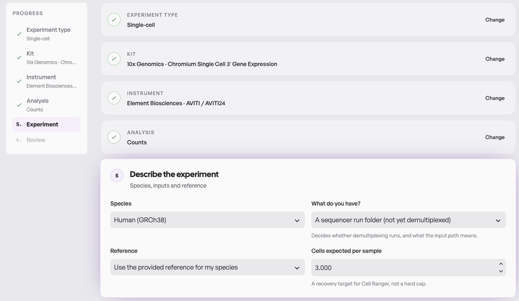

1. *01*

   **Experiment, kit, instrument**What you ran, and on which platform
2. *02*

   **Analysis**Chosen from verified modules
3. *03*

   **Samples and metadata**What goes in, described once
4. *04*

   **Review and run**Result, quality report and dossier, in your own environment

[figure not shown]

Data Intuitive · Booth 30

SKALDU

## Ready for the future.

Typical road · biomarker from R&D to diagnostic**5 to 10 years**

Discovery Analytical validation Clinical validation Quality system and IVDR Deployment Routine use

**Tier 1 · R&D** Live today

Versioned, tested, every run recorded.

**Tier 2 · Clinical** Preparing, 2028 at the earliest

Part 11 signatures, validation package, GxP mode, change impact.  
**Validation starts from evidence, not a blank page.**

**Tier 3 · Diagnostics** Health institutions · open today · from 31 Dec 2030, justification per patient group

**IVDR 5(5)**: the institution makes the test and decides.

[figure not shown]

Data Intuitive · Booth 30

SKALDU

## Research runs today. Paid use from Q2 2027. Clinical from 2028 at the earliest.

**Live today**At top-five pharma, as consultancy

**Now to Q2 2027**Open use, for feedback

**Q2 2027**London launch, paid use

**Q4 2027**AI assistant for new modules · Flanders grant

**2028**Clinical earliest · diagnostics open now

We never claim validated, compliant or clinical ready.

[figure not shown]

Data Intuitive · Booth 30

SKALDU

One foundation, one analysis platform across instruments and assays.

## Your data stays yours. Every run stays reproducible.

Who wrote your analysis

Could you rerun that analysis from three years ago?

With us, yes: **reproducible by design.**  
Same code, same versions, years later.

Where is your data

Want to really own all your data?

Your own cloud or your own site. **We hold no copy and no keys.**  
ISO 27001 certified handling.

Current status

We deliver custom projects with the SKALDU interface now. Paid platform access from Q2 2027.

Visit us

**Booth 30, next to this stage. We run an assay with you.**

1 / 7